# MA 321-7 ; Applied Statistics ; Team Project ; Group 2 - Team C

#### PART 2: Unsupervised Learning:

**II) Use unsupervised learning models/clustering to investigate clusters/groups of genes and clusters/groups of patients. Apply Principal Component Analysis, k-means clustering and hierarchical clustering. You may add one further method.**

**Principal Component Analysis - Creating a Model:**

```r
# Performing PCA on the cleaned and imputed dataset, excluding the last column
pcaResult <- prcomp(filtered_df_w_class[,-ncol(filtered_df_w_class)], center = TRUE, scale. = TRUE)
summary(pcaResult)
```

```
## Importance of components:
##                            PC1    PC2     PC3     PC4     PC5     PC6     PC7
## Standard deviation     13.0223 9.8284 9.25056 8.76649 7.59301 6.76422 6.56015
## Proportion of Variance  0.1187 0.0676 0.05988 0.05378 0.04035 0.03202 0.03012
## Cumulative Proportion   0.1187 0.1863 0.24615 0.29993 0.34028 0.37230 0.40241
##                            PC8     PC9    PC10    PC11    PC12    PC13    PC14
## Standard deviation     6.43962 5.88419 5.55992 5.34519 5.21624 5.05868 4.80252
## Proportion of Variance 0.02902 0.02423 0.02163 0.01999 0.01904 0.01791 0.01614
## Cumulative Proportion  0.43143 0.45566 0.47729 0.49729 0.51633 0.53424 0.55038
##                           PC15    PC16    PC17    PC18    PC19    PC20   PC21
## Standard deviation     4.74818 4.66365 4.62757 4.53056 4.44574 4.36092 4.3106
## Proportion of Variance 0.01578 0.01522 0.01499 0.01436 0.01383 0.01331 0.0130
## Cumulative Proportion  0.56615 0.58137 0.59636 0.61072 0.62455 0.63786 0.6509
##                           PC22    PC23    PC24    PC25    PC26    PC27    PC28
## Standard deviation     4.21539 4.13073 4.07541 3.98923 3.96891 3.90878 3.84235
## Proportion of Variance 0.01243 0.01194 0.01162 0.01114 0.01102 0.01069 0.01033
## Cumulative Proportion  0.66330 0.67524 0.68686 0.69800 0.70902 0.71971 0.73005
##                           PC29    PC30    PC31    PC32    PC33    PC34    PC35
## Standard deviation     3.72961 3.70281 3.62993 3.61303 3.51768 3.47629 3.43040
## Proportion of Variance 0.00973 0.00959 0.00922 0.00914 0.00866 0.00846 0.00823
## Cumulative Proportion  0.73978 0.74937 0.75859 0.76773 0.77639 0.78485 0.79308
##                           PC36    PC37    PC38    PC39    PC40    PC41    PC42
## Standard deviation     3.37112 3.33194 3.31362 3.29383 3.22428 3.17435 3.15009
## Proportion of Variance 0.00795 0.00777 0.00768 0.00759 0.00727 0.00705 0.00694
## Cumulative Proportion  0.80103 0.80880 0.81649 0.82408 0.83135 0.83840 0.84535
##                           PC43    PC44    PC45    PC46    PC47    PC48    PC49
## Standard deviation     3.10326 3.05101 3.00554 2.98243 2.94585 2.92674 2.88405
## Proportion of Variance 0.00674 0.00651 0.00632 0.00622 0.00607 0.00599 0.00582
## Cumulative Proportion  0.85209 0.85860 0.86492 0.87115 0.87722 0.88322 0.88904
##                           PC50    PC51    PC52   PC53    PC54    PC55    PC56
## Standard deviation     2.85896 2.81952 2.78296 2.7791 2.76539 2.70510 2.67489
## Proportion of Variance 0.00572 0.00556 0.00542 0.0054 0.00535 0.00512 0.00501
## Cumulative Proportion  0.89476 0.90032 0.90574 0.9111 0.91649 0.92162 0.92662
##                           PC57   PC58    PC59    PC60    PC61    PC62    PC63
## Standard deviation     2.61270 2.5917 2.53919 2.49525 2.45853 2.42539 2.40288
## Proportion of Variance 0.00478 0.0047 0.00451 0.00436 0.00423 0.00412 0.00404
## Cumulative Proportion  0.93140 0.9361 0.94061 0.94497 0.94920 0.95332 0.95736
##                           PC64    PC65    PC66    PC67    PC68    PC69    PC70
## Standard deviation     2.35260 2.29672 2.28423 2.23989 2.19872 2.14353 2.09731
## Proportion of Variance 0.00387 0.00369 0.00365 0.00351 0.00338 0.00322 0.00308
## Cumulative Proportion  0.96123 0.96492 0.96857 0.97208 0.97547 0.97868 0.98176
##                           PC71    PC72   PC73    PC74    PC75    PC76    PC77
## Standard deviation     2.06713 2.02591 2.0012 1.94920 1.89281 1.80437 1.74541
## Proportion of Variance 0.00299 0.00287 0.0028 0.00266 0.00251 0.00228 0.00213
## Cumulative Proportion  0.98475 0.98762 0.9904 0.99308 0.99559 0.99787 1.00000
##                             PC78
## Standard deviation     5.783e-15
## Proportion of Variance 0.000e+00
## Cumulative Proportion  1.000e+00
```

**Visualizing Points Across Top 2 Principal Components:**

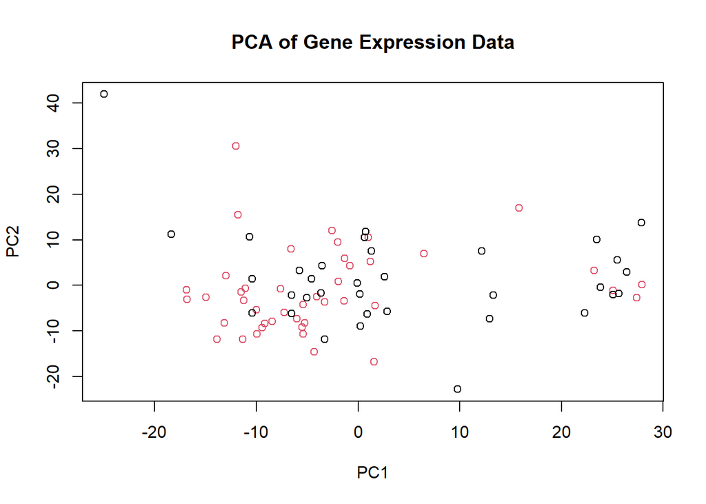

```r
# Plot PCA, coloring by the class variable that shows clusters
plot(pcaResult$x[,1:2], col = as.factor(filtered_df_w_class[,ncol(filtered_df_w_class)]))
title("PCA of Gene Expression Data")
```

**Features Before and After Performing PCA:**

```r
# Before PCA: Count the number of original variables (excluding the class variable)
num_original_variables <- ncol(filtered_df_w_class) - 1
print(paste("Number of original variables:", num_original_variables))
```

```
## [1] "Number of original variables: 1429"
```

```r
# After PCA: Determine the number of principal components based on a variance threshold
explained_variance <- summary(pcaResult)$importance[2,]
cumulative_explained_variance <- cumsum(explained_variance)
variance_threshold <- 0.80 # for example, 80% of the variance
num_components_needed <- which(cumulative_explained_variance >= variance_threshold)[1]
print(paste("Number of components needed to explain at least", variance_threshold * 100, "% of the variance:", num_components_needed))
```

```
## [1] "Number of components needed to explain at least 80 % of the variance: 36"
```

**Plotting Explained Variance by Each Component:**

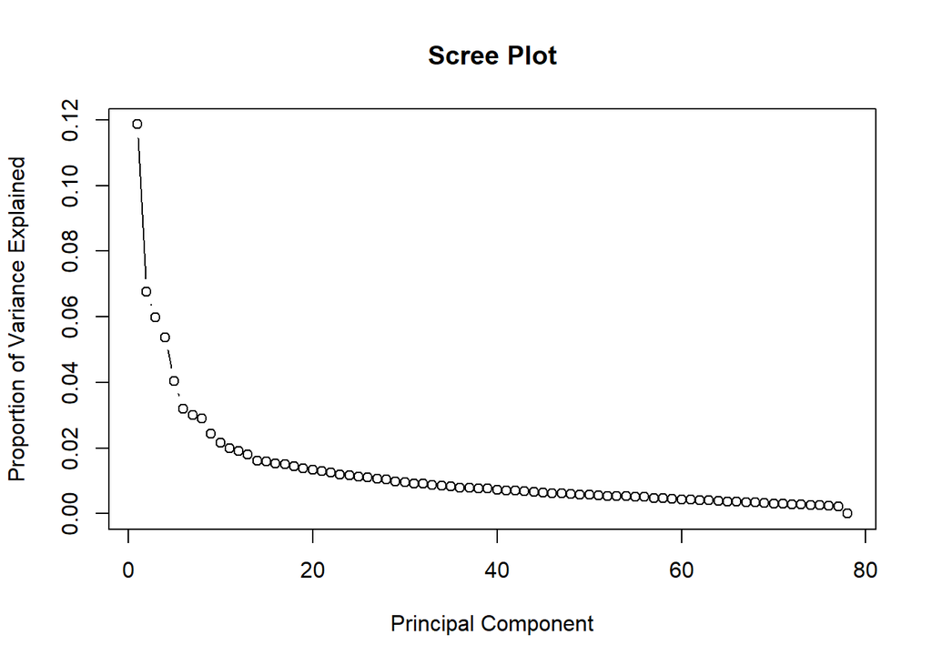

```r
# Optionally, plot a scree plot to visually inspect the variance explained by each component
plot(explained_variance, type = "b", xlab = "Principal Component", ylab = "Proportion of Variance Explained", main = "Scree Plot")
abline(h = variance_threshold, col = "red", lty = 2) # Add a horizontal line at the variance threshold
```

**Agglomerative Clustering - Creating the Model:**

```r
# Exclude the class/label column from the clustering input
DataForClustering <- pca_df_w_class[, !names(pca_df_w_class) %in% c('Class')]

# Calculate distance matrix using Euclidean distance
d <- dist(DataForClustering, method = "euclidean")

# Perform agglomerative clustering using Ward's method
hc <- hclust(d, method = "ward.D2")

# Increasing plot margins to ensure clarity
par(mar=c(5,4,4,8) + 0.1)  # Adjust the margins (bottom, left, top, right)
```

**Plotting the Clusters:**

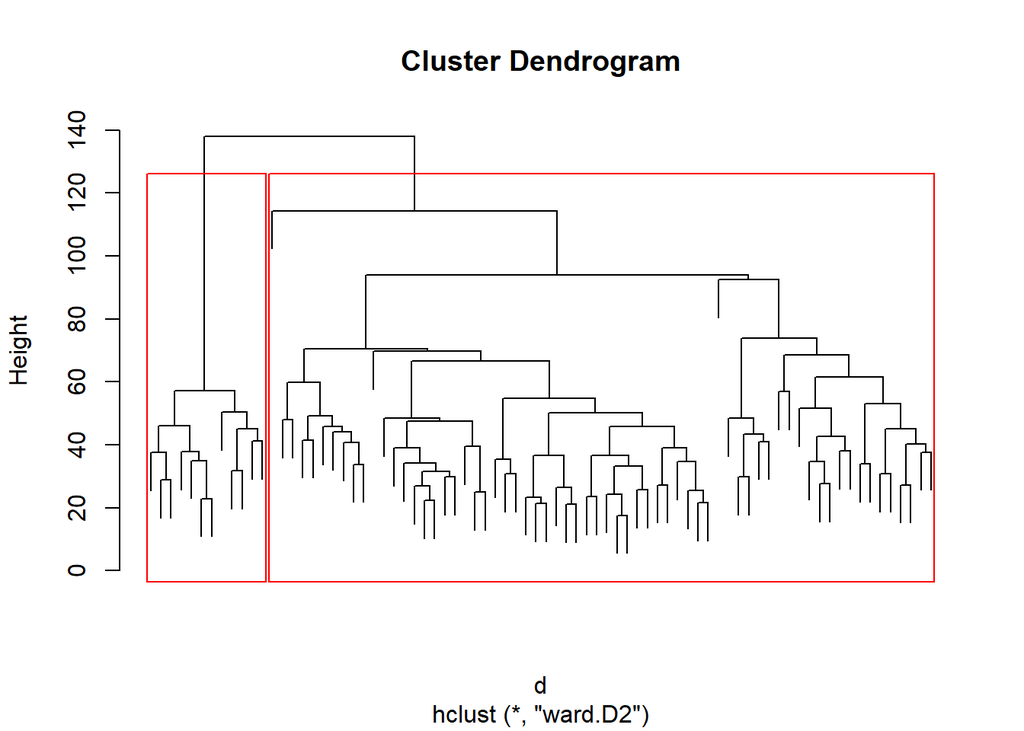

```r
# Plot the dendrogram with enhanced clarity
plot(hc, labels=FALSE, cex=0.6)  # Adjust cex for label size if labels are used

# Choose the number of clusters k based on your analysis or requirement
k <- 2
rect.hclust(hc, k=k, border="red")  # Add colored rectangles around clusters
```

**Exporting Dendogram as PDF:**

```r
# Exporting the dendrogram to a PDF for high-quality output
pdf("dendrogram.pdf", width=10, height=8)
plot(hc, labels=FALSE)
rect.hclust(hc, k=k, border="red")  # Optionally, add colored rectangles again for the PDF output
dev.off()  # Close the PDF device
```

**K-Means Clustering - Creating the Model:**

```r
# Specify the number of clusters
k <- 3

# Perform k-means clustering
kmeans_result <- kmeans(pcaResult$x[, 1:2], centers = k)
```

```r
# Convert the first 2 principal components to a data frame
kmeans_df_pca <- as.data.frame(pcaResult$x[, 1:2])

# Add k-means as a new factor column in the PCA data frame
kmeans_df_pca$cluster <- as.factor(kmeans_result$cluster)
```

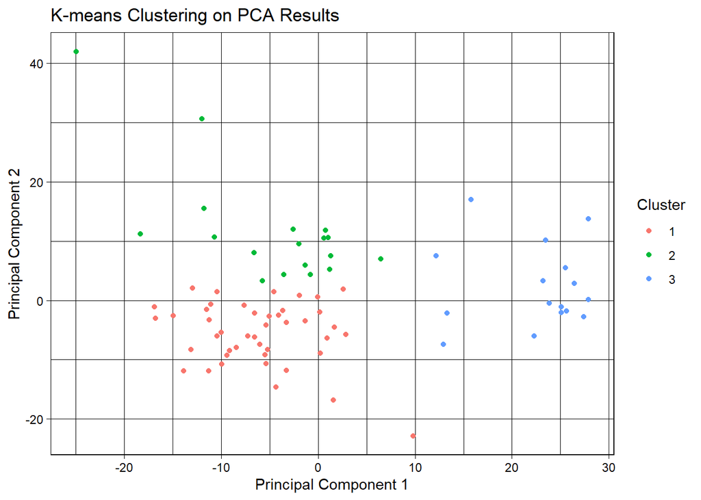

```r
# Plot using ggplot2
kmeans_plot <- ggplot(kmeans_df_pca, aes(x = PC1, y = PC2, color = cluster)) +
  geom_point(alpha = 1) +  theme_linedraw() + labs(title = "K-means Clustering on PCA Results",
      x = "Principal Component 1",
       y = "Principal Component 2") +
  scale_color_discrete(name = "Cluster")

kmeans_plot
```

```r
# Save plot
ggsave("k-means.png", plot = kmeans_plot, width = 10, height = 8, units = "in")
```

**Hierarchical Clustering - Creating the Model:**

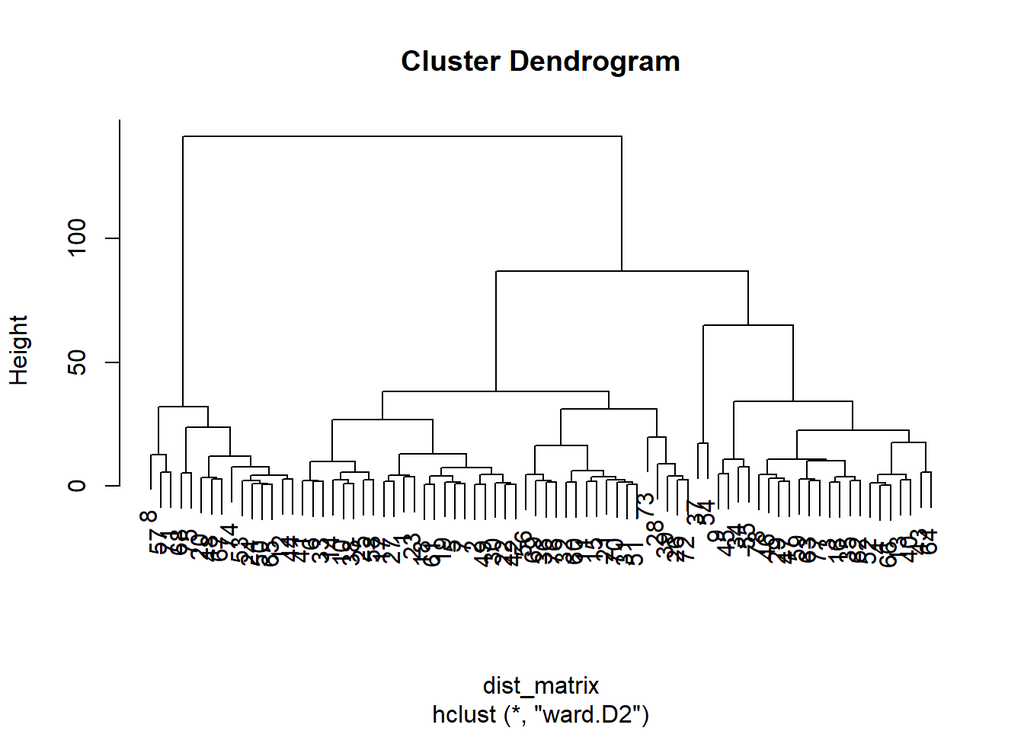

```r
# Create another data frame with first 2 principal components
df_hclust <- data.frame(PC1 = pcaResult$x[, 1], PC2 = pcaResult$x[, 2])

# Compute the distance matrix
dist_matrix <- dist(df_hclust, method = "euclidean")

# Perform hierarchical clustering
hc_result <- hclust(dist_matrix, method = "ward.D2")

# Plot the dendrogram
plot(hc_result)
```

```r
# Specify the number of clusters
k <- 3

# Cut the dendrogram tree into 'k' clusters
clusters <- cutree(hc_result, k = k)

# Add the cluster assignments as a new factor column
df_hclust$cluster <- as.factor(clusters)
```

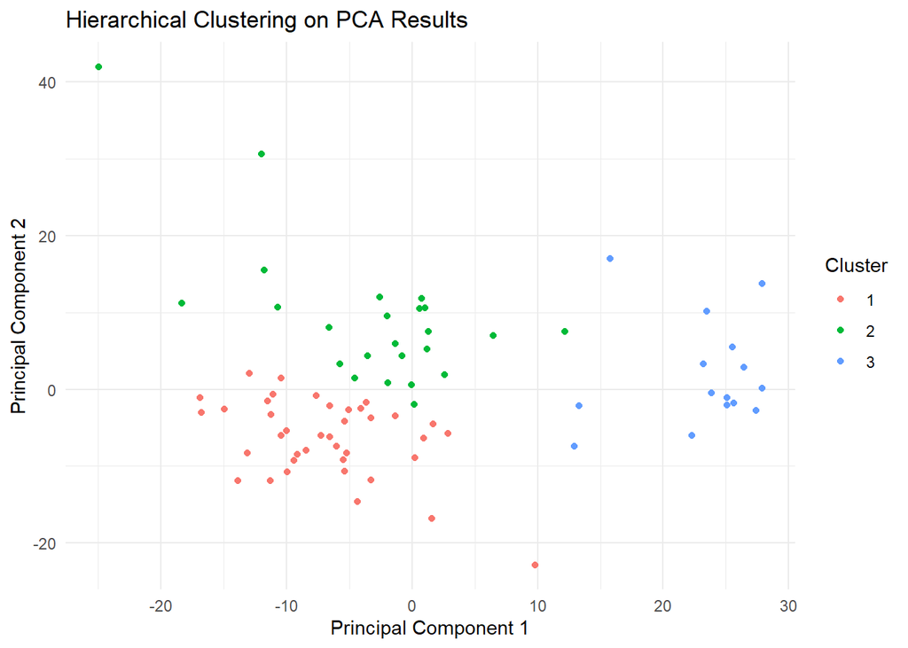

```r
# Plot using ggplot2
ggplot(df_hclust, aes(x = PC1, y = PC2, color = cluster)) +
  geom_point() +
  theme_minimal() +
  labs(title = "Hierarchical Clustering on PCA Results",
       x = "Principal Component 1",
       y = "Principal Component 2") +
  scale_color_discrete(name = "Cluster")
```

**T-SNE Clustering - Creating the Model:**

```r
tsne_result <- Rtsne(pca_df_w_class, dims = 2, perplexity = 10, verbose = TRUE)
```

```
## Performing PCA
## Read the 78 x 37 data matrix successfully!
## OpenMP is working. 1 threads.
## Using no_dims = 2, perplexity = 10.000000, and theta = 0.500000
## Computing input similarities...
## Building tree...
## Done in 0.00 seconds (sparsity = 0.550625)!
## Learning embedding...
## Iteration 50: error is 68.400485 (50 iterations in 0.01 seconds)
## Iteration 100: error is 77.085138 (50 iterations in 0.01 seconds)
## Iteration 150: error is 74.987794 (50 iterations in 0.01 seconds)
## Iteration 200: error is 71.066682 (50 iterations in 0.01 seconds)
## Iteration 250: error is 71.874469 (50 iterations in 0.01 seconds)
## Iteration 300: error is 2.776082 (50 iterations in 0.00 seconds)
## Iteration 350: error is 2.112234 (50 iterations in 0.00 seconds)
## Iteration 400: error is 1.761509 (50 iterations in 0.00 seconds)
## Iteration 450: error is 1.578410 (50 iterations in 0.00 seconds)
## Iteration 500: error is 1.440502 (50 iterations in 0.00 seconds)
## Iteration 550: error is 1.264310 (50 iterations in 0.00 seconds)
## Iteration 600: error is 1.145408 (50 iterations in 0.00 seconds)
## Iteration 650: error is 1.051270 (50 iterations in 0.00 seconds)
## Iteration 700: error is 0.969101 (50 iterations in 0.00 seconds)
## Iteration 750: error is 0.916154 (50 iterations in 0.00 seconds)
## Iteration 800: error is 0.889137 (50 iterations in 0.00 seconds)
## Iteration 850: error is 0.841490 (50 iterations in 0.00 seconds)
## Iteration 900: error is 0.801222 (50 iterations in 0.00 seconds)
## Iteration 950: error is 0.780065 (50 iterations in 0.00 seconds)
## Iteration 1000: error is 0.748513 (50 iterations in 0.00 seconds)
## Fitting performed in 0.09 seconds.
```

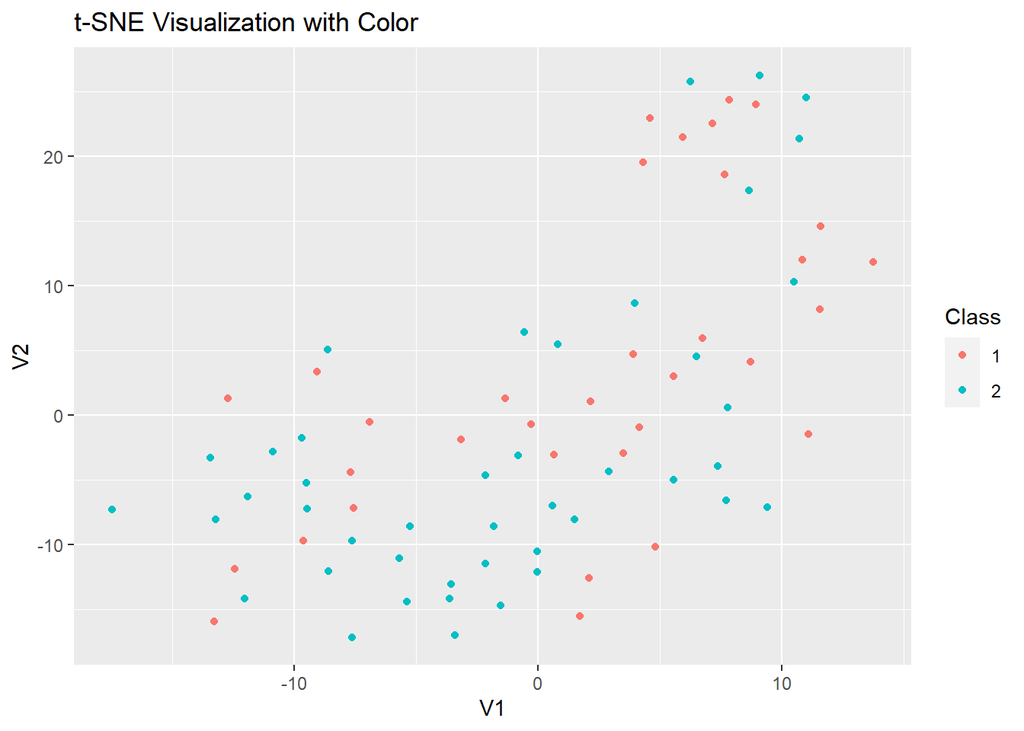

```r
tsne_df <- as.data.frame(tsne_result$Y)

ggplot(tsne_df, aes(x = V1, y = V2, color = as.factor(pca_df_w_class$Class))) +
  geom_point() +
  labs(title = "t-SNE Visualization with Color") +
  scale_color_discrete(name = "Class")
```

#### PART 3: Supervised Learning:

**III) Use supervised learning models/classification to predict the class (invasive or non invasive) of future patients. Apply Logistic Regression, LDA, QDA, k-NN, Random Forest and SVM. Discuss why you choose specific hyper parameters of a supervised learning model. You may add one or two further methods to the investigation. Use resampling techniques to compare the machine learning models applied. Suggest and justify your ‘best’ machine learning model.**

**Preparing Dataset:**

```r
# Loading dataset
df <- pca_df_w_class

# Converting class label to factor with two levels
df$Class <- factor(df$Class)

str(df)
```

```
## 'data.frame':    78 obs. of  37 variables:
##  $ PC1  : num  -13.14 -9.99 -1.32 1.01 -5.24 ...
##  $ PC2  : num  -8.28 -5.43 5.92 10.56 -8.32 ...
##  $ PC3  : num  2.105 -1.513 1.64 0.462 -3.095 ...
##  $ PC4  : num  -2.63 4.61 -2.29 7.23 2.05 ...
##  $ PC5  : num  1.21 3.74 -14.16 2.21 8.71 ...
##  $ PC6  : num  -0.655 -5.21 -3.009 6.988 9.965 ...
##  $ PC7  : num  9.59 7.18 5.64 13.62 -11.09 ...
##  $ PC8  : num  -3.25 -5.09 -6.56 -0.65 2.97 ...
##  $ PC9  : num  -1.045 0.375 -7.463 -11.066 -2.377 ...
##  $ PC10 : num  0.676 4.419 -2.173 -7.456 3.187 ...
##  $ PC11 : num  -2.76 3.38 3.69 -12.05 -4.37 ...
##  $ PC12 : num  4.227 -3.51 -6.277 0.171 -0.255 ...
##  $ PC13 : num  -1.05 3.14 -3.66 2.77 1.14 ...
##  $ PC14 : num  0.233 -1.721 -0.508 0.446 -0.989 ...
```

[output cut: 23 more lines]

```r
# Checking class distribution
class_distribution <- table(df$Class)
class_distribution
```

```
##
##  1  2
## 34 44
```

```r
# Setting Seed for reproducibility
registration_number <- 2315740 #Mantosh
set.seed(registration_number)

# Splitting into train & test sets
train_index <- sample(1:nrow(df), 0.80 * nrow(df))
train_data <- df[train_index, ]
test_data <- df[-train_index, ]

class_distribution_train <- table(train_data$Class)
class_distribution_train
```

```
##
##  1  2
## 31 31
```

```r
class_distribution_test <- table(test_data$Class)
class_distribution_test
```

```
##
##  1  2
##  3 13
```

**Creating and Tuning Logistic Regression Model:**

```r
# Define control parameters for model
lr_ctrl <- trainControl(method = "cv", number = 3)  # 3-fold cross-validation

# Creating Logistic Regression model
lr <- train(Class ~ ., data = train_data, method = "glmnet", trControl = lr_ctrl)
lr_best_model <- lr

# Print cross-validation results
print(lr_best_model$results)
```

```
##   alpha       lambda  Accuracy      Kappa AccuracySD   KappaSD
## 1  0.10 0.0003237639 0.5681818 0.13636364 0.12373325 0.2474665
## 2  0.10 0.0032376387 0.5681818 0.13636364 0.12373325 0.2474665
## 3  0.10 0.0323763870 0.5696970 0.13939394 0.14780301 0.2956060
## 4  0.55 0.0003237639 0.5666667 0.13333333 0.07637626 0.1527525
## 5  0.55 0.0032376387 0.5515152 0.10303030 0.09773608 0.1954722
## 6  0.55 0.0323763870 0.5651515 0.13030303 0.07691539 0.1538308
## 7  1.00 0.0003237639 0.6151515 0.23030303 0.07837889 0.1567578
## 8  1.00 0.0032376387 0.5833333 0.16666667 0.10408330 0.2081666
## 9  1.00 0.0323763870 0.5363636 0.07272727 0.12103206 0.2420641
```

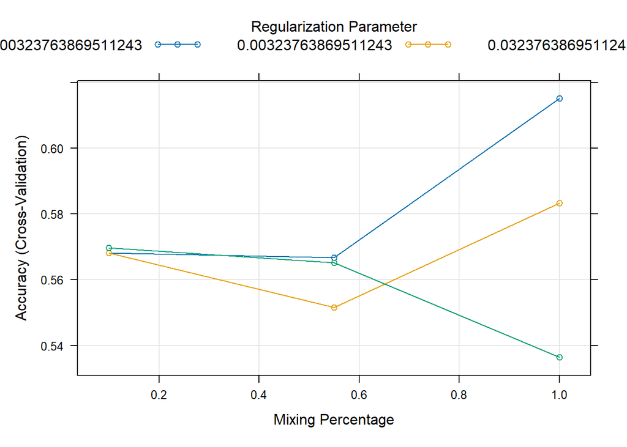

```r
# Plotting accuracy vs. hyperparameters
plot(lr_best_model)
```

```r
# Selecting the best model (not required for logistic regression)
# Logistic regression does not require selecting the best model

# Making predictions of Logistic Regression model
lr_predictions <- predict(lr_best_model, newdata = test_data)

# Evaluating the Logistic Regression model
lr_confusion_matrix <- table(Actual = test_data$Class, Predicted = lr_predictions)
lr_confusion_matrix
```

```
##       Predicted
## Actual 1 2
##      1 2 1
##      2 5 8
```

```r
# Accuracy calculation of Logistic Regression model
lr_accuracy <- sum(diag(lr_confusion_matrix)) / sum(lr_confusion_matrix)
lr_accuracy
```

```
## [1] 0.625
```

**Creating and Tuning Linear Discriminant (LDA) Model:**

```r
# Defining control parameters for model
lda_ctrl <- trainControl(method = "cv", number = 3)  # 3-fold cross validation

# Training LDA model
lda <- train(Class ~ ., data = train_data, method = "lda" ,
             trControl = lda_ctrl)
lda_best_model <- lda


# Printing cross-validation results
print(lda$results)
```

```
##   parameter  Accuracy     Kappa AccuracySD  KappaSD
## 1      none 0.5793651 0.1644245  0.0836163 0.170718
```

```r
#Making predictions of LDA model
lda_predictions <- predict(lda_best_model, newdata = test_data)

# Evaluating the model
lda_confusion_matrix <- table(Actual = test_data$Class, Predicted = lda_predictions)
lda_confusion_matrix
```

```
##       Predicted
## Actual 1 2
##      1 2 1
##      2 4 9
```

```r
# Accuracy calculation
lda_accuracy <- sum(diag(lda_confusion_matrix)) / sum(lda_confusion_matrix)
lda_accuracy
```

```
## [1] 0.6875
```

**CREATING AND TUNING NAIVE BAYES MODEL FOR BEST RESULT:**

```r
# Defining control parameters for model
nb_ctrl <- trainControl(method = "cv", number = 3)  # 3-fold cross validation

# Training Naive Bayes model
nb <- train(Class ~ ., data = train_data, method = "naive_bayes",
            trControl = nb_ctrl)
nb_best_model <- nb

# Printing cross-validation results
print(nb_best_model$results)
```

```
##   usekernel laplace adjust  Accuracy       Kappa AccuracySD   KappaSD
## 1     FALSE       0      1 0.4833333 -0.03333333 0.07637626 0.1527525
## 2      TRUE       0      1 0.5954545  0.19090909 0.08294676 0.1658935
```

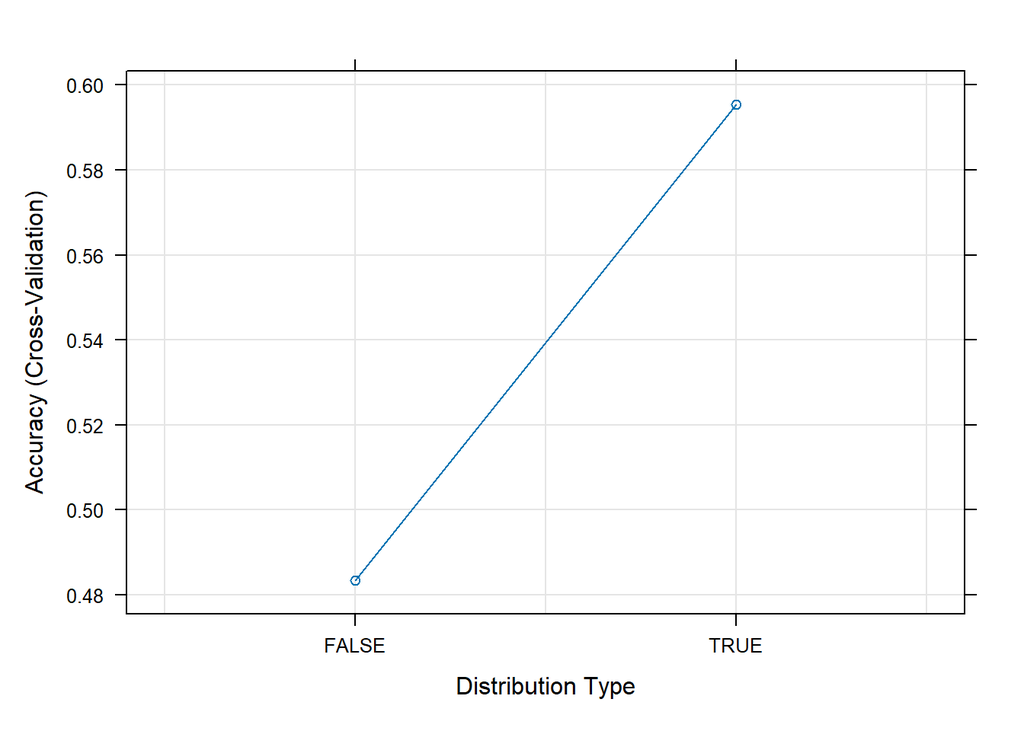

```r
# Plotting accuracy
plot(nb_best_model)
```

```r
# Making predictions of Naive Bayes model
nb_predictions <- predict(nb_best_model, newdata = test_data)

# Evaluating the model
nb_confusion_matrix <- table(Actual = test_data$Class, Predicted = nb_predictions)
nb_confusion_matrix
```

```
##       Predicted
## Actual 1 2
##      1 1 2
##      2 4 9
```

```r
# Accuracy calculation
nb_accuracy <- sum(diag(nb_confusion_matrix)) / sum(nb_confusion_matrix)
nb_accuracy
```

```
## [1] 0.625
```

**CREATING AND TUNING K NEAREST NEIGHBORS MODEL FOR BEST RESULT:**

```r
# Defining control parameters for model
knn_ctrl <- trainControl(method = "cv", number = 3)  # 3-fold cross validation

# Training KNN model with grid search for hyper-parameter tuning
k_values <- c(1, 2, 3, 4, 5 , 6, 7, 8, 9 , 10, 11, 12, 13 , 14 , 15, 20)
knn <- train(Class ~ ., data = train_data, method = "knn",
             trControl = knn_ctrl,
             tuneGrid = expand.grid(k = k_values))

# Printing cross-validation results
print(knn$results)
```

```
##     k  Accuracy      Kappa AccuracySD    KappaSD
## 1   1 0.5636364 0.12727273 0.05529784 0.11059568
## 2   2 0.5424242 0.08484848 0.16771023 0.33542046
## 3   3 0.6727273 0.34545455 0.13552774 0.27105548
## 4   4 0.6424242 0.28484848 0.07348094 0.14696189
## 5   5 0.6590909 0.31818182 0.06412153 0.12824305
## 6   6 0.6424242 0.28484848 0.08887884 0.17775769
## 7   7 0.6772727 0.35454545 0.02530802 0.05061604
## 8   8 0.6560606 0.31212121 0.15917747 0.31835493
## 9   9 0.6242424 0.24848485 0.12859165 0.25718330
## 10 10 0.5606061 0.12121212 0.11627245 0.23254491
## 11 11 0.5924242 0.18484848 0.11942816 0.23885632
## 12 12 0.6287879 0.25757576 0.02584655 0.05169310
## 13 13 0.5772727 0.15454545 0.09392717 0.18785435
## 14 14 0.6257576 0.25151515 0.11555948 0.23111897
## 15 15 0.5621212 0.12424242 0.06898517 0.13797033
## 16 20 0.5484848 0.09696970 0.05006882 0.10013765
```

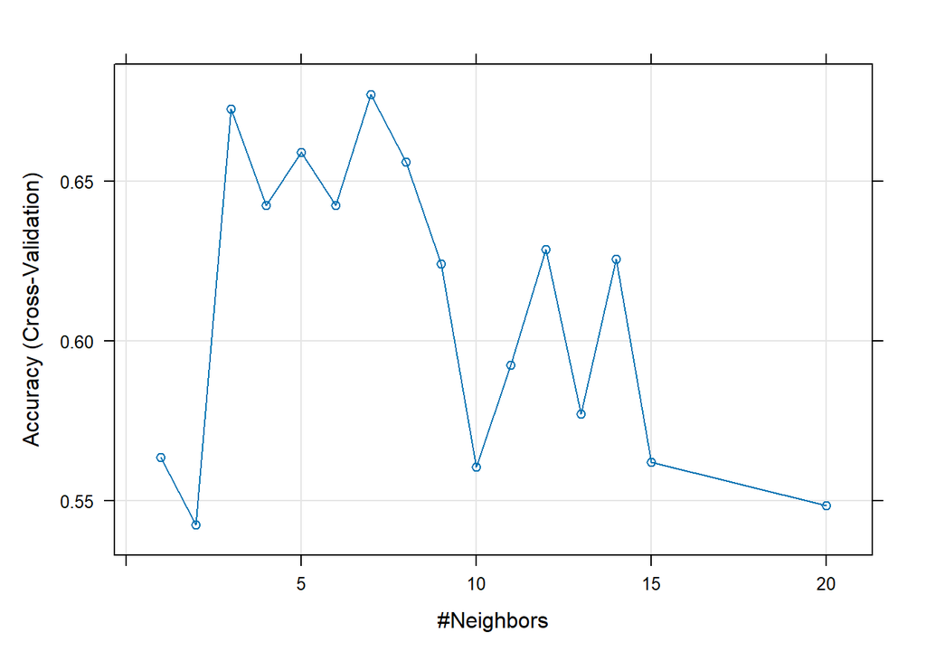

```r
# Plotting accuracy vs. k
plot(knn)
```

```r
# Selecting the best model
best_k <- knn$bestTune$k
knn_best_model <- train(Class ~ ., data = train_data, method = "knn",
                  trControl = knn_ctrl,
                  tuneGrid = data.frame(k = best_k))
knn_best_model
```

```
## k-Nearest Neighbors
##
## 62 samples
## 36 predictors
##  2 classes: '1', '2'
##
## No pre-processing
## Resampling: Cross-Validated (3 fold)
## Summary of sample sizes: 41, 41, 42
## Resampling results:
##
##   Accuracy   Kappa
##   0.5325397  0.07312172
##
## Tuning parameter 'k' was held constant at a value of 7
```

```r
#Making predictions of knn Model
knn_predictions <- predict(knn_best_model, newdata = test_data)

# Evaluating the model
knn_confusion_matrix <- table(Actual = test_data$Class, Predicted = knn_predictions)
knn_confusion_matrix
```

```
##       Predicted
## Actual  1  2
##      1  3  0
##      2  2 11
```

```r
# Accuracy calculation
knn_accuracy <- sum(diag(knn_confusion_matrix)) / sum(knn_confusion_matrix)
knn_accuracy
```

```
## [1] 0.875
```

**CREATING AND TUNING SVM MODEL FOR BEST RESULT:**

```r
# Defining control parameters for model
svm_ctrl <- trainControl(method = "cv", number = 3)  # 3-fold cross validation

# Training SVM model
svm_grid <- expand.grid(sigma = runif(10, 0.1, 2), C = 10^runif(10, -2, 2))
svm <- train(Class ~ .,data = train_data, method = "svmRadial",
                  trControl = svm_ctrl,
                  tuneGrid = svm_grid)

# Printing cross-validation results
print(svm$results)
```

```
##         sigma           C  Accuracy       Kappa AccuracySD    KappaSD
## 1   0.1007622  0.02505485 0.5341270  0.10000000 0.10034898 0.17320508
## 2   0.1007622  0.02703130 0.5341270  0.10000000 0.10034898 0.17320508
## 3   0.1007622  0.04728802 0.5341270  0.10000000 0.10034898 0.17320508
## 4   0.1007622  0.17798175 0.5341270  0.10000000 0.10034898 0.17320508
## 5   0.1007622  0.24807464 0.5341270  0.10000000 0.10034898 0.17320508
## 6   0.1007622  6.19387869 0.6126984  0.23554572 0.01099715 0.03096186
## 7   0.1007622  6.33143872 0.6126984  0.23554572 0.01099715 0.03096186
## 8   0.1007622  6.65874937 0.6126984  0.23554572 0.01099715 0.03096186
## 9   0.1007622 10.60017542 0.6126984  0.23554572 0.01099715 0.03096186
## 10  0.1007622 83.51410509 0.6126984  0.23554572 0.01099715 0.03096186
## 11  0.2009877  0.02505485 0.5341270  0.10000000 0.10034898 0.17320508
## 12  0.2009877  0.02703130 0.5341270  0.10000000 0.10034898 0.17320508
## 13  0.2009877  0.04728802 0.5341270  0.10000000 0.10034898 0.17320508
## 14  0.2009877  0.17798175 0.5341270  0.10000000 0.10034898 0.17320508
```

[output cut: 86 more lines]

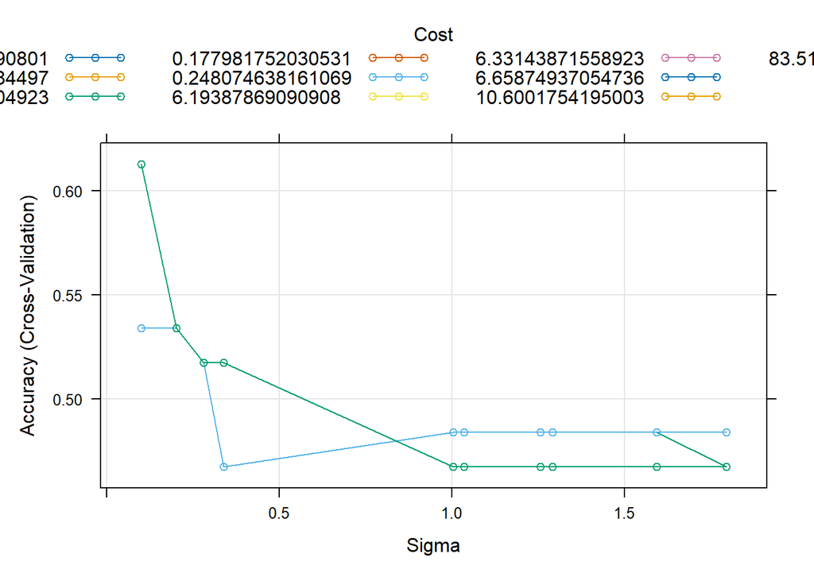

```r
# Plotting accuracy vs cost/sigma
plot(svm)
```

```r
# Extracting the best model
best_sigma <- svm$bestTune$sigma
best_C <- svm$bestTune$C

svm_best_model <- train(Class ~ .,  data = train_data, method = "svmRadial",
                        trControl = svm_ctrl,
                        tuneGrid = data.frame(sigma = best_sigma, C = best_C))

#Making predictions of SVM MODEL
svm_predictions <- predict(svm_best_model, newdata = test_data)

# Evaluating the SVM MODEL
svm_confusion_matrix <- table(Actual = test_data$Class, Predicted = svm_predictions)
svm_confusion_matrix
```

```
##       Predicted
## Actual 1 2
##      1 3 0
##      2 7 6
```

```r
# Accuracy calculation
svm_accuracy <- sum(diag(svm_confusion_matrix)) / sum(svm_confusion_matrix)
svm_accuracy
```

```
## [1] 0.5625
```

**CREATING AND TUNING RANDOM FOREST MODEL FOR BEST RESULT:**

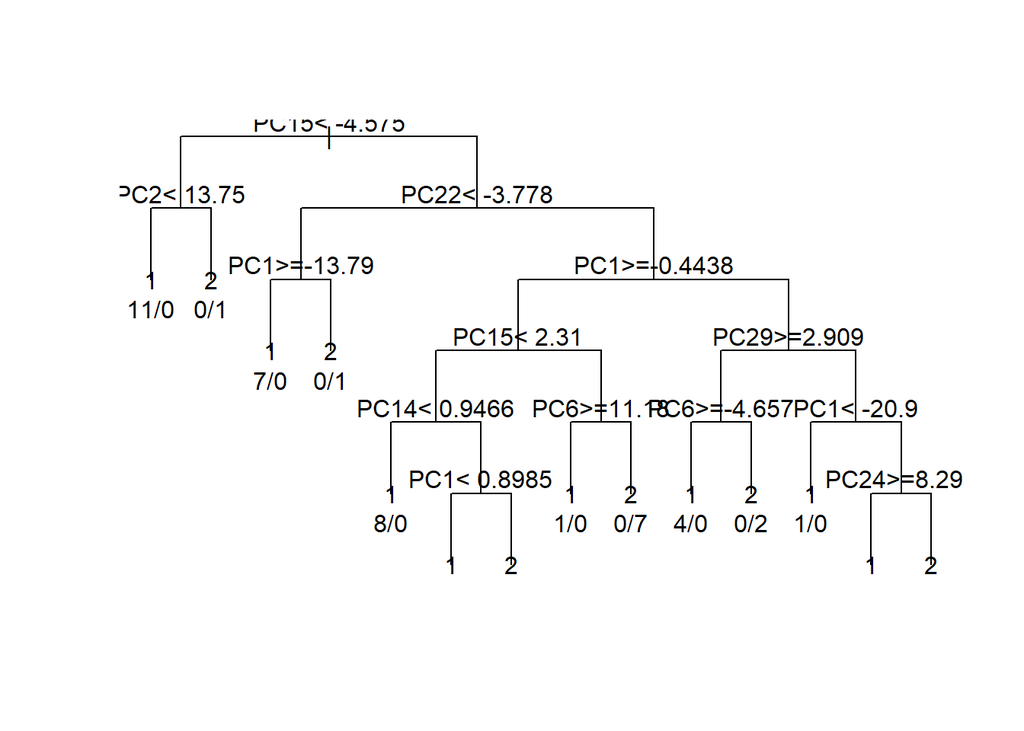

```r
# Creating a sample decision tree
tree <- rpart(Class ~. , method = "class" , control = rpart.control(cp = 0 , minsplit = 1) , data = df)
plot(tree, uniform = TRUE)
text(tree, use.n = TRUE)
```

```r
# Defining control parameters for model

# Using bootstrapping for cross validation by taking 500 samples
# mtry = number of features to include in creating random forests
# ntree = number of trees

rf_ctrl <- trainControl(method = "cv", number = 3)  # 3-fold cross validation

# Training Random Forest model with grid search for hyper-parameter tuning
rf_tune_grid <- expand.grid(mtry = seq(1, ncol(train_data) - 1))

rf <- train(Class ~ ., data = train_data, method = "rf", ntree = 500,
            trControl = rf_ctrl,
            tuneGrid = rf_tune_grid)

# Printing cross-validation results
print(rf$results)
```

```
##    mtry  Accuracy        Kappa AccuracySD    KappaSD
## 1     1 0.5801587  0.167747748 0.03534197 0.07193523
## 2     2 0.5333333  0.075541854 0.06245180 0.11847681
## 3     3 0.5468254  0.098569870 0.08716801 0.17785557
## 4     4 0.4984127  0.002432127 0.08849117 0.18007567
## 5     5 0.5476190  0.101598793 0.04123930 0.08831491
## 6     6 0.5484127  0.102173474 0.02384917 0.04924215
## 7     7 0.5634921  0.132121212 0.05991932 0.12062281
## 8     8 0.5166667  0.035901826 0.03741960 0.08075229
## 9     9 0.4658730 -0.064015152 0.10034898 0.20454651
## 10   10 0.5325397  0.066502867 0.01512108 0.02932629
## 11   11 0.5468254  0.095662100 0.08716801 0.17862186
## 12   12 0.5150794  0.035765460 0.06118322 0.12456873
## 13   13 0.4825397 -0.028416290 0.08589047 0.18058932
## 14   14 0.4515873 -0.097189085 0.11905556 0.24059232
```

[output cut: 22 more lines]

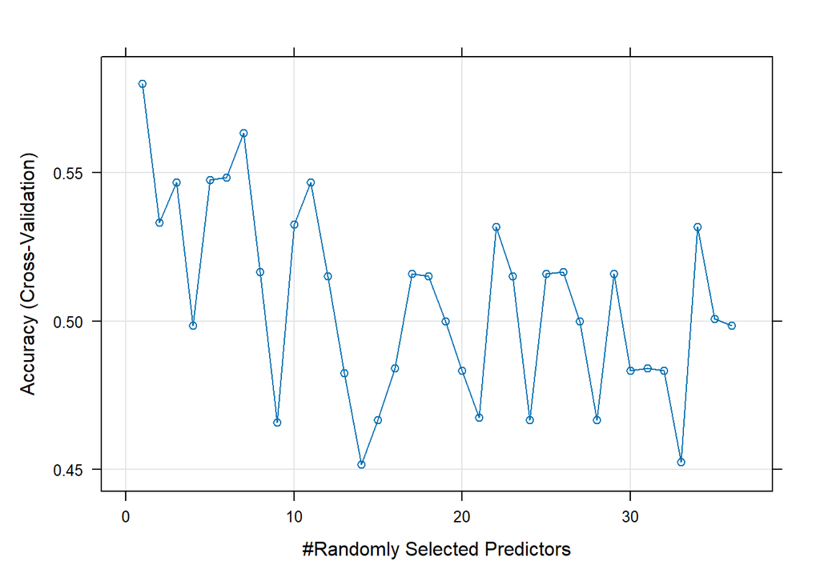

```r
# Plotting accuracy vs. mtry
plot(rf)
```

```r
# Selecting the best model
best_mtry <- rf$bestTune$mtry
rf_best_model <- train(Class ~ ., data = train_data, method = "rf",
                       trControl = rf_ctrl,
                       tuneGrid = data.frame(mtry = best_mtry))
rf_best_model
```

```
## Random Forest
##
## 62 samples
## 36 predictors
##  2 classes: '1', '2'
##
## No pre-processing
## Resampling: Cross-Validated (3 fold)
## Summary of sample sizes: 41, 42, 41
## Resampling results:
##
##   Accuracy   Kappa
##   0.6126984  0.2285345
##
## Tuning parameter 'mtry' was held constant at a value of 1
```

```r
#Making predictions
rf_predictions <- predict(rf_best_model, newdata = test_data)

# Evaluating the model
rf_confusion_matrix <- table(Actual = test_data$Class, Predicted = rf_predictions)
rf_confusion_matrix
```

```
##       Predicted
## Actual 1 2
##      1 1 2
##      2 5 8
```

```r
# Accuracy calculation
rf_accuracy <- sum(diag(rf_confusion_matrix)) / sum(rf_confusion_matrix)
rf_accuracy
```

```
## [1] 0.5625
```

**CREATING AND TUNING XG BOOST MODEL FOR BEST RESULT:**

```r
# Defining control parameters for model
xgb_ctrl <- trainControl(method = "cv", number = 3)  # 3-fold cross validation

# Training XGBoost model with hyperparameters
xgb <- train(Class ~ ., data = train_data, method = "xgbTree",
             trControl = xgb_ctrl,
             tuneLength = 3)  # Tune over a limited number of parameter combinations
```

[output not shown]

[output cut: 161 more lines]

[output not shown]

```r
# Printing cross-validation results
print(xgb$results)
```

```
##     eta max_depth gamma colsample_bytree min_child_weight subsample nrounds
## 1   0.3         1     0              0.6                1      0.50      50
## 4   0.3         1     0              0.6                1      0.75      50
## 7   0.3         1     0              0.6                1      1.00      50
## 10  0.3         1     0              0.8                1      0.50      50
## 13  0.3         1     0              0.8                1      0.75      50
## 16  0.3         1     0              0.8                1      1.00      50
## 55  0.4         1     0              0.6                1      0.50      50
## 58  0.4         1     0              0.6                1      0.75      50
## 61  0.4         1     0              0.6                1      1.00      50
## 64  0.4         1     0              0.8                1      0.50      50
## 67  0.4         1     0              0.8                1      0.75      50
## 70  0.4         1     0              0.8                1      1.00      50
## 19  0.3         2     0              0.6                1      0.50      50
## 22  0.3         2     0              0.6                1      0.75      50
```

[output cut: 203 more lines]

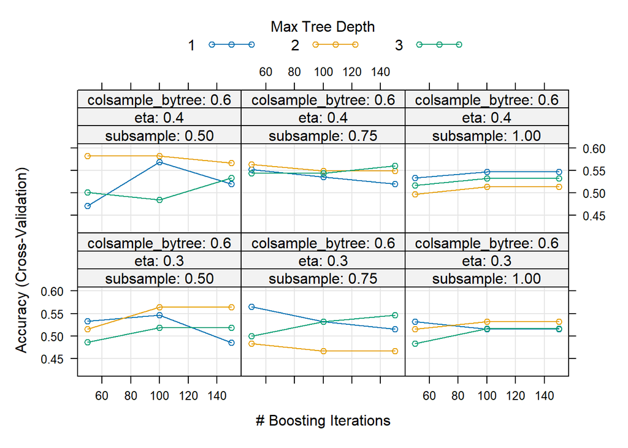

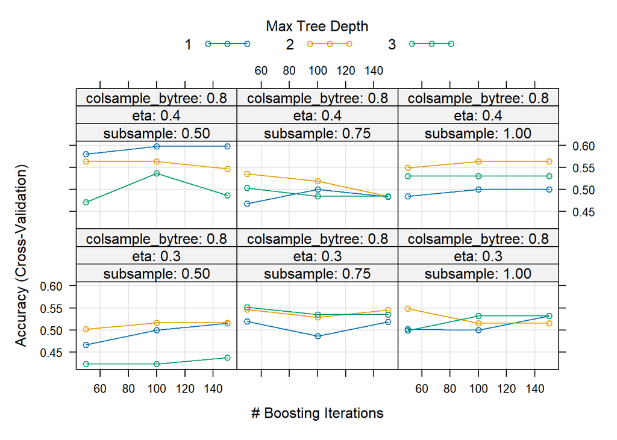

```r
# Plotting accuracy vs. hyperparameters
plot(xgb)
```

```r
# Making predictions
xgb_predictions <- predict(xgb, newdata = test_data)

# Evaluating the model
xgb_confusion_matrix <- table(Actual = test_data$Class, Predicted = xgb_predictions)
xgb_confusion_matrix
```

```
##       Predicted
## Actual 1 2
##      1 3 0
##      2 5 8
```

```r
# Accuracy calculation
xgb_accuracy <- sum(diag(xgb_confusion_matrix)) / sum(xgb_confusion_matrix)
xgb_accuracy
```

```
## [1] 0.6875
```

**Resampling & Evaluating All Models Agaisnt Accuracy:**

```r
# Create a list of trained models
models <- list(
  Logistic_Regression = lr_best_model,
  LDA = lda_best_model,
  Naive_Bayes = nb_best_model,
  KNN = knn_best_model,
  SVM = svm_best_model,
  Random_Forest = rf_best_model,
  XB_Boost = xgb
  )

# Evaluate models on multiple datasets
model_eval <- resamples(models, data = datasets, method = "accuracy")

# Summarize results
summary(model_eval)
```

```
##
## Call:
## summary.resamples(object = model_eval)
##
## Models: Logistic_Regression, LDA, Naive_Bayes, KNN, SVM, Random_Forest, XB_Boost
## Number of resamples: 3
##
## Accuracy
##                          Min.   1st Qu.    Median      Mean   3rd Qu.      Max.
## Logistic_Regression 0.5454545 0.5727273 0.6000000 0.6151515 0.6500000 0.7000000
## LDA                 0.5000000 0.5357143 0.5714286 0.5793651 0.6190476 0.6666667
## Naive_Bayes         0.5000000 0.5681818 0.6363636 0.5954545 0.6431818 0.6500000
## KNN                 0.4761905 0.5130952 0.5500000 0.5325397 0.5607143 0.5714286
## SVM                 0.5000000 0.5595238 0.6190476 0.5952381 0.6428571 0.6666667
## Random_Forest       0.5714286 0.5857143 0.6000000 0.6126984 0.6333333 0.6666667
## XB_Boost            0.5500000 0.5704545 0.5909091 0.5969697 0.6204545 0.6500000
##                     NA's
## Logistic_Regression    0
## LDA                    0
## Naive_Bayes            0
## KNN                    0
## SVM                    0
## Random_Forest          0
## XB_Boost               0
##
## Kappa
##                            Min.    1st Qu.    Median       Mean   3rd Qu.
## Logistic_Regression  0.09090909 0.14545455 0.2000000 0.23030303 0.3000000
## LDA                  0.00000000 0.07623318 0.1524664 0.16442451 0.2466368
## Naive_Bayes          0.00000000 0.13636364 0.2727273 0.19090909 0.2863636
## KNN                 -0.01762115 0.04118943 0.1000000 0.07312172 0.1184932
## SVM                  0.00000000 0.11111111 0.2222222 0.19154838 0.2873226
## Random_Forest        0.14479638 0.17239819 0.2000000 0.22853452 0.2704036
## XB_Boost             0.10000000 0.14090909 0.1818182 0.19393939 0.2409091
##                          Max. NA's
## Logistic_Regression 0.4000000    0
## LDA                 0.3408072    0
## Naive_Bayes         0.3000000    0
## KNN                 0.1369863    0
## SVM                 0.3524229    0
## Random_Forest       0.3408072    0
## XB_Boost            0.3000000    0
```

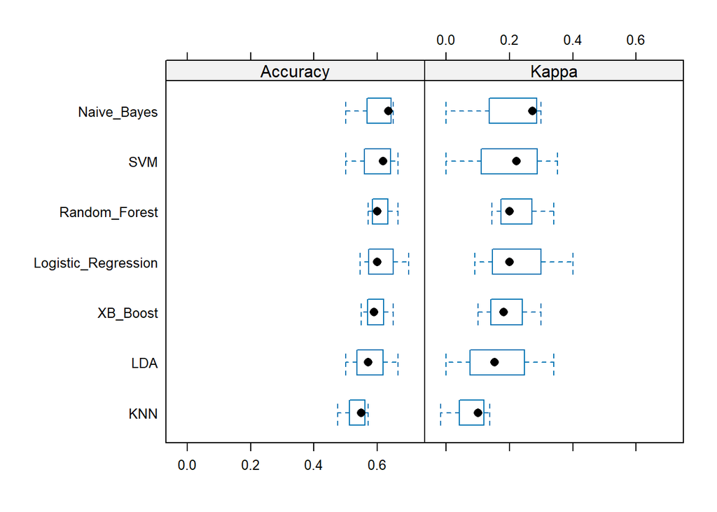

```r
# Visualize results
bwplot(model_eval)
```

**Evaluating All Models:**

```r
model_predictions <- lapply(models, function(model) {
  predict(model, newdata = test_data)
})

# Evaluate performance metrics (e.g., accuracy, precision, recall) on the testing dataset for each model
model_metrics <- lapply(model_predictions, function(predictions) {
  confusionMatrix(predictions, test_data$Class)
})

# Model metrics
model_metrics
```

```
## $Logistic_Regression
## Confusion Matrix and Statistics
##
##           Reference
## Prediction 1 2
##          1 2 5
##          2 1 8
##
##                Accuracy : 0.625
##                  95% CI : (0.3543, 0.848)
##     No Information Rate : 0.8125
##     P-Value [Acc > NIR] : 0.9810
##
##                   Kappa : 0.1864
##
##  Mcnemar's Test P-Value : 0.2207
##
##             Sensitivity : 0.6667
##             Specificity : 0.6154
##          Pos Pred Value : 0.2857
##          Neg Pred Value : 0.8889
##              Prevalence : 0.1875
##          Detection Rate : 0.1250
##    Detection Prevalence : 0.4375
##       Balanced Accuracy : 0.6410
##
##        'Positive' Class : 1
##
##
## $LDA
## Confusion Matrix and Statistics
##
##           Reference
## Prediction 1 2
##          1 2 4
##          2 1 9
##
##                Accuracy : 0.6875
##                  95% CI : (0.4134, 0.8898)
##     No Information Rate : 0.8125
```

[output cut: 147 more lines]

```
##                   Kappa : 0.375
##
##  Mcnemar's Test P-Value : 0.07364
##
##             Sensitivity : 1.0000
##             Specificity : 0.6154
##          Pos Pred Value : 0.3750
##          Neg Pred Value : 1.0000
##              Prevalence : 0.1875
##          Detection Rate : 0.1875
##    Detection Prevalence : 0.5000
##       Balanced Accuracy : 0.8077
##
##        'Positive' Class : 1
##
```

```r
# Model Accuracy on test dataset
model_accuracy_test_dataset <- sapply(model_metrics, function(metrics) {
  metrics$overall["Accuracy"]
})

# Compare performance metrics of models
model_accuracy_test_dataset
```

```
## Logistic_Regression.Accuracy                 LDA.Accuracy
##                       0.6250                       0.6875
##         Naive_Bayes.Accuracy                 KNN.Accuracy
##                       0.6250                       0.8750
##                 SVM.Accuracy       Random_Forest.Accuracy
##                       0.5625                       0.5625
##            XB_Boost.Accuracy
##                       0.6875
```

```r
# Get the name of the best model based on accuracy
best_model_name <- names(model_accuracy_test_dataset[model_accuracy_test_dataset == max(model_accuracy_test_dataset)])

# Print the best model based on accuracy
print("Best model based on accuracy:")
```

```
## [1] "Best model based on accuracy:"
```

```r
print(best_model_name)
```

```
## [1] "KNN.Accuracy"
```

#### PART 4: Investigating Best Machine Learning Model:

**IV) Investigate if clusters established under II) improve your ‘best’ machine learning model.**

```r
# Setting seed for reproducibility
set.seed(2315740)

# Converting class label to factor with two levels
df2 <- filtered_df_w_class
df2$Class <- factor(df2$Class)

# Splitting dataset into test and train
raw_train_index <- sample(1:nrow(df2), 0.80 * nrow(df2))
raw_train_data <- df2[raw_train_index, ]
raw_test_data <- df2[-raw_train_index, ]
```

**Testing KNN Model on Raw Dataset (Non-Dimensionally Reduced):**

```r
# Defining control parameters for model
raw_knn_ctrl <- trainControl(method = "cv", number = 3)  # 3-fold cross validation

# Training KNN model with grid search for hyper-parameter tuning
raw_k_values <- c(1, 2, 3, 4, 5 , 6, 7, 8, 9 , 10, 11, 12, 13 , 14 , 15, 20)
raw_knn <- train(Class ~ ., data = raw_train_data, method = "knn",
             trControl = raw_knn_ctrl,
             tuneGrid = expand.grid(k = raw_k_values))

# Printing cross-validation results
print(raw_knn$results)
```

```
##     k  Accuracy      Kappa AccuracySD    KappaSD
## 1   1 0.5666667 0.13333333 0.05773503 0.11547005
## 2   2 0.6151515 0.23030303 0.06035935 0.12071869
## 3   3 0.5666667 0.13333333 0.07637626 0.15275252
## 4   4 0.5181818 0.03636364 0.05511071 0.11022142
## 5   5 0.6121212 0.22424242 0.02099456 0.04198911
## 6   6 0.6136364 0.22727273 0.03181818 0.06363636
## 7   7 0.6121212 0.22424242 0.05422888 0.10845776
## 8   8 0.6287879 0.25757576 0.02584655 0.05169310
## 9   9 0.5787879 0.15757576 0.07061321 0.14122643
## 10 10 0.6257576 0.25151515 0.15282014 0.30564028
## 11 11 0.6090909 0.21818182 0.11390876 0.22781753
## 12 12 0.5803030 0.16060606 0.02663393 0.05326787
## 13 13 0.6090909 0.21818182 0.11390876 0.22781753
## 14 14 0.5787879 0.15757576 0.07061321 0.14122643
## 15 15 0.6242424 0.24848485 0.12859165 0.25718330
## 16 20 0.5121212 0.02424242 0.10759710 0.21519419
```

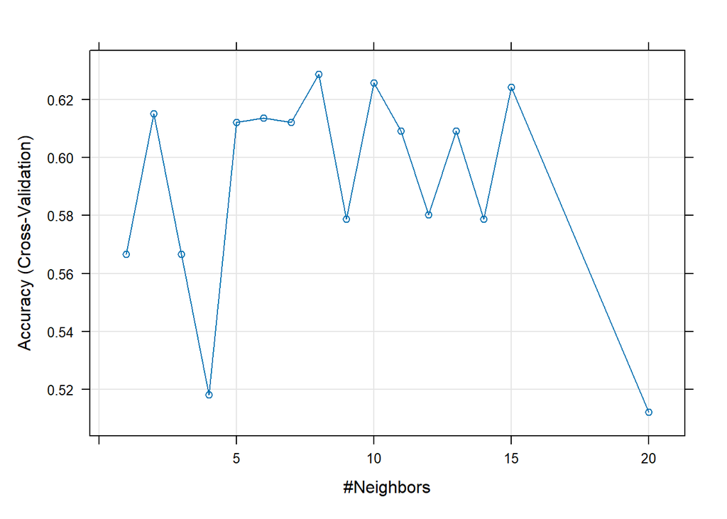

```r
# Plotting accuracy vs. k
plot(raw_knn)
```

```r
# Selecting the best model
raw_best_k <- raw_knn$bestTune$k
raw_knn_best_model <- train(Class ~ ., data = raw_train_data, method = "knn",
                  trControl = raw_knn_ctrl,
                  tuneGrid = data.frame(k = raw_best_k))
raw_knn_best_model
```

```
## k-Nearest Neighbors
##
##   62 samples
## 1429 predictors
##    2 classes: '1', '2'
##
## No pre-processing
## Resampling: Cross-Validated (3 fold)
## Summary of sample sizes: 42, 40, 42
## Resampling results:
##
##   Accuracy   Kappa
##   0.6151515  0.230303
##
## Tuning parameter 'k' was held constant at a value of 8
```

```r
#Making predictions of knn Model
raw_knn_predictions <- predict(raw_knn_best_model, newdata = raw_test_data)

# Evaluating the model
raw_knn_confusion_matrix <- table(Actual = raw_test_data$Class, Predicted = raw_knn_predictions)
raw_knn_confusion_matrix
```

```
##       Predicted
## Actual  1  2
##      1  2  1
##      2  3 10
```

```r
# Accuracy calculation
raw_knn_accuracy <- sum(diag(raw_knn_confusion_matrix)) / sum(raw_knn_confusion_matrix)
raw_knn_accuracy
```

```
## [1] 0.75
```

**Comparing Results of Best KNN Model on Dimensioanlly Reduced vs Raw Dataset:**

```r
# Calculating precision, recall, and F1-score for KNN model trained on the raw dataset
raw_knn_conf_mat <- raw_knn_confusion_matrix
raw_knn_precision <- raw_knn_conf_mat[2, 2] / sum(raw_knn_conf_mat[, 2])
raw_knn_recall <- raw_knn_conf_mat[2, 2] / sum(raw_knn_conf_mat[2, ])
raw_knn_f1_score <- 2 * (raw_knn_precision * raw_knn_recall) / (raw_knn_precision + raw_knn_recall)

cat("KNN Model on Raw Dataset:\n")
```

```
## KNN Model on Raw Dataset:
```

```r
cat("Accuracy:", raw_knn_accuracy, "\n")
```

```
## Accuracy: 0.75
```

```r
cat("Precision:", raw_knn_precision, "\n")
```

```
## Precision: 0.9090909
```

```r
cat("Recall:", raw_knn_recall, "\n")
```

```
## Recall: 0.7692308
```

```r
cat("F1-score:", raw_knn_f1_score, "\n")
```

```
## F1-score: 0.8333333
```

```r
# Calculating precision, recall, and F1-score for KNN model trained on the dimensionally reduced dataset
knn_conf_mat <- knn_confusion_matrix
knn_precision <- knn_conf_mat[2, 2] / sum(knn_conf_mat[, 2])
knn_recall <- knn_conf_mat[2, 2] / sum(knn_conf_mat[2, ])
knn_f1_score <- 2 * (knn_precision * knn_recall) / (knn_precision + knn_recall)

cat("KNN Model on Dimensioanlly Reduced Dataset:\n")
```

```
## KNN Model on Dimensioanlly Reduced Dataset:
```

```r
cat("Accuracy:", knn_accuracy, "\n")
```

```
## Accuracy: 0.875
```

```r
cat("Precision:", knn_precision, "\n")
```

```
## Precision: 1
```

```r
cat("Recall:", knn_recall, "\n")
```

```
## Recall: 0.8461538
```

```r
cat("F1-score:", knn_f1_score, "\n")
```

```
## F1-score: 0.9166667
```

**Plotting and Checking ROC/AUC for Both Models:**

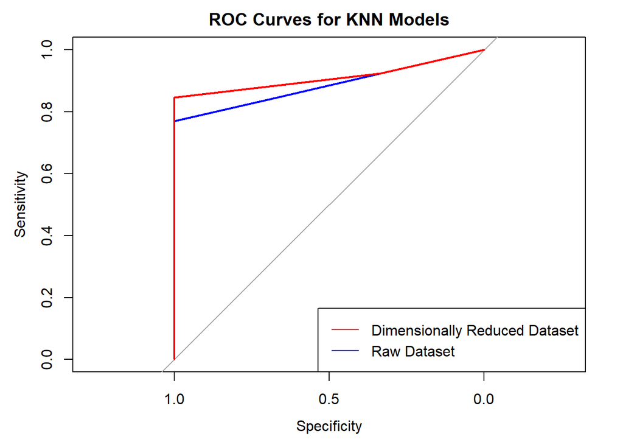

```r
# Plotting ROC curves for both models

# Calculating predicted probabilities for both models
raw_knn_pred_probs <- predict(raw_knn_best_model, newdata = raw_test_data, type = "prob")[, "1"]
knn_pred_probs <- predict(knn_best_model, newdata = test_data, type = "prob")[, "1"]

# Plotting ROC curves
raw_roc_knn <- roc(raw_test_data$Class, raw_knn_pred_probs)
roc_knn <- roc(test_data$Class, knn_pred_probs)
plot(raw_roc_knn, col = "blue", main = "ROC Curves for KNN Models")
plot(roc_knn, col = "red", add = TRUE)
legend("bottomright", legend = c("Dimensionally Reduced Dataset", "Raw Dataset"), col = c("red", "blue"), lty = 1)
```

```r
# Calculating AUC for both models
raw_auc_knn <- auc(raw_roc_knn)
auc_knn <- auc(roc_knn)

cat("\nKNN Model AUC on Raw Dataset:", raw_auc_knn, "\n")
```

```
##
## KNN Model AUC on Raw Dataset: 0.8846154
```

```r
cat("KNN Model AUC on Dimensionally Reduced Dataset:", auc_knn, "\n")
```

```
## KNN Model AUC on Dimensionally Reduced Dataset: 0.9102564
```